Kurs: *Digitale Geschichte des Holocaust*

# Digitale Lücken und Grenzen

## „Opferdatenbanken“ kritisch lesen

Michal Frankl

Wien, 22. 1. 2024

Im Jupyter-Notebook geschrieben, kodiert, visualisiert und presentiert.

[figure not shown]

## Wikidata Abfrage: „Holocaust victims“

```python
query = """
SELECT DISTINCT ?item ?itemLabel WHERE {
  SERVICE wikibase:label { bd:serviceParam wikibase:language "en". }
  {
    SELECT DISTINCT ?item WHERE {
      ?item p:P2868 ?statement0.
      ?statement0 (ps:P2868/(wdt:P279*)) wd:Q5883980.
    }
  }
}
"""
```

## Wikidata result

```python
results_df[['item.value', 'itemLabel.value']].head(10)
```

|  | item.value | itemLabel.value |
| --- | --- | --- |
| 0 | http://www.wikidata.org/entity/Q104207778 | Friedrich Ackermann |
| 1 | http://www.wikidata.org/entity/Q104207956 | Alfred Adler |
| 2 | http://www.wikidata.org/entity/Q104207960 | Alfred Adler |
| 3 | http://www.wikidata.org/entity/Q104208223 | Rudolf Adler |
| 4 | http://www.wikidata.org/entity/Q104208226 | Rudolf Adler |
| 5 | http://www.wikidata.org/entity/Q104207770 | Arthur Ackermann |
| 6 | http://www.wikidata.org/entity/Q104207883 | Alfréd Adel |
| 7 | http://www.wikidata.org/entity/Q104207773 | Franziska Ackermann |
| 8 | http://www.wikidata.org/entity/Q104207898 | Alfred Adelberg |
| 9 | http://www.wikidata.org/entity/Q104207822 | Esther Acohen Bella |

### Insgesamt gefunden in Wikidata

```python
print(len(results_df.index))
```

```
128896
```

Entspricht 1.17 % von "humans" in Wikidata.

### Beispiel: Hilda Engelová

[figure not shown]

## Kurs: *Digitale Geschichte des Holocaust*

- Geschichte der personen-bezogene Datensätze der Verfolgten: ethische Aspekte, methodologische Fragen, thematische Lücken
- Wandel der Geschichtsschreibung im Rahmen der digitalen Revolution, digitale Quellenkritik
- Formen und Herausforderungen der Datenerfassung, Standardisierung und Publikation; digitale Tools für Datenverwaltung, Auswertung und Visualisierung

## Fragen für die Diskussion

- Führt das *digital turn* zu inklusiven Forschungs- und Erinnerungspraktiken?
- Welche Lücken und Brüche in den Datenbanken der Verfolgten erwarten bzw. finden wir und warum?
- Welche Diskurse und Hierarchien beeinflussen die Namenserfassung?
- Wie können solche Lücken identifiziert und korrigiert werden?

## Gedenkstätte für die in der Shoa ermordeten Jüdischen Kinder, Frauen und Männer aus Österreich

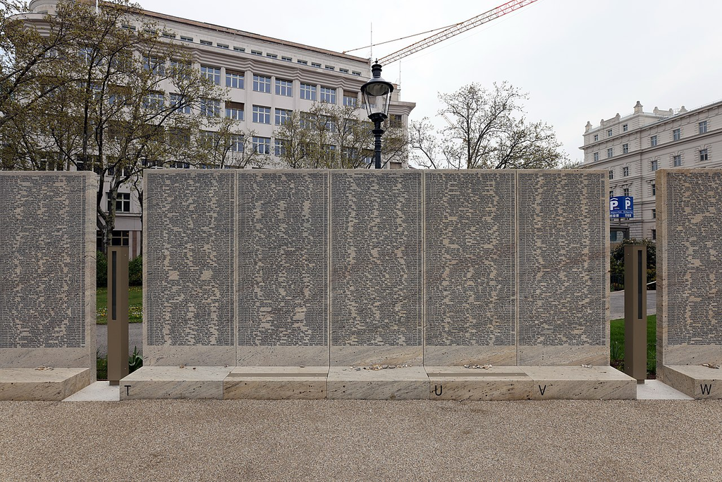

```python
display.Image(response['thumbnail']['url'], width="500")
```

Kasa Fue - https://commons.wikimedia.org/wiki/File:Gedenkst%C3%A4tte_Shoah_%C3%96sterreich_Wien_April_2022_Sue-Vi.jpg

## Protokolle an der österreischisch-tschechoslowakischen Grenze

[figure not shown]

```python
hnanice
```

Make this Notebook Trusted to load map: File -> Trust Notebook

[interactive chart not shown]

## In Hnanice / Gnadlersdorf abgewiesene Flüchtlinge

```python
df[['Nachn.', 'Vorn.', 'Geburtsdatum', 'Geburtsort', 'Geschlecht', 'Staatsbürgerschaft', 'Letzte Wohnadresse']]
```

|  | Nachn. | Vorn. | Geburtsdatum | Geburtsort | Geschlecht | Staatsbürgerschaft | Letzte Wohnadresse |
| --- | --- | --- | --- | --- | --- | --- | --- |
| 0 | S | V | 1878-11-12 | Wien | M | ohne | Wien II., Zirkusgasse 50 |
| 1 | S | B | NaN | NaN | M | ohne | Wien |
| 2 | S | J | 1895-09-06 | Vasilovce, Bezirk Viniza, Polsko | M | ohne | Wien |
| 3 | S | NaN | NaN | NaN | F | ohne | Wien |
| 4 | S | NaN | NaN | NaN | child | ohne | Wien |
| 5 | S | NaN | NaN | NaN | child | ohne | Wien |
| 6 | W | V | 1899-11-30 | Wien | M | ohne | Wien II., Taborstr. 51 |
| 7 | W | O | 1898-03-12 | Wien | M | ohne | Wien II., Taborstr. 51 |
| 8 | U | A | 1907-03-15 00:00:00 | Dzialoszyn, Polen | M | polnisch | Milano, Corso Genova 20 |
| 9 | H | J | 1903-09-17 00:00:00 | Brzeziny Lodzkie, Polen | M | polnisch | Paris |
| 10 | G | A | NaN | NaN | M | polnisch | NaN |
| 11 | B | J | NaN | NaN | M | ohne | NaN |
| 12 | S | P | 1895-08-06 | Sadagura, Bezirk Černovice, Polen | M | ohne | Wien II., Ausstellungsstrasse 5 |
| 13 | T | S | 1912-05-24 00:00:00 | Köln | M | polnisch | Dreiskirchen 28 |
| 14 | L | D | 1898-01-21 | Chrzanów, Polen | M | ohne | Wien II., Ferdinandstrasse 17 |
| 15 | G | S | 1903-08-29 00:00:00 | Krakov, Polen | M | polnisch | Wien II., Schiffamtsgasse 6 |
| 16 | R | P | 1886-10-14 | Tarnopol, Polen | F | polnisch | Wien XX., Heinzelmanngasse 18/12 |
| 17 | R | R | 1913-12-29 00:00:00 | Przemysl, Polen | F | polnisch | Wien XX., Heinzelmanngasse 18/12 |
| 18 | R | S | 1920-06-19 00:00:00 | Wien | F | polnisch | Wien XX., Heinzelmanngasse 18/12 |
| 19 | K | H | 1897-12-06 | Stopczatów, Polen | M | polnisch | Wien XX., Dammstrasse 38 |
| 20 | D | N | 1883-01-01 | Berdyczow, Russland | M | polnisch | Wien III., Fasangasse 20 |
| 21 | B | S | 1904-11-29 00:00:00 | Kolomea, Polen | M | polnisch | Wien II, Glockengasse 41 |
| 22 | M | M | 1910-09-17 00:00:00 | Mannheim, Deutschland | M | polnisch | Wien II., Hollandstrasse 10 |
| 23 | M | L | 1901-04-15 00:00:00 | Lwow, Galizien | M | polnisch | Wien II., Vereinsgasse 2 |

### Staatsbürgerschaft

```python
df.groupby(['Staatsbürgerschaft'])['Staatsbürgerschaft'].count()
```

```
Staatsbürgerschaft
ohne        11
polnisch    13
Name: Staatsbürgerschaft, dtype: int64
```

### Gender und Alter

```python
df.groupby(['Geschlecht'])['Geschlecht'].count()
```

```
Geschlecht
F         4
M        18
child     2
Name: Geschlecht, dtype: int64
```

### Gefunden in Datenbanken

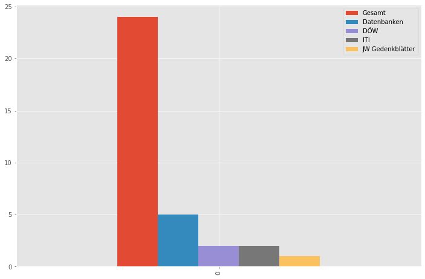

```python
hdbs.plot(kind='bar')
```

## Protokol mit Samuel Meyer Tugendreich

[figure not shown]

Archiv des Aussenministeriums der Tschechischen Republik, Sektion V, K. 411.

### Texterkennung

```python
text = pytesseract.image_to_string(image, lang='ces')
print(text)
```

```
A M5 KOXSLÍRÁ LÁZÁ Vele

Samuel Weyer Tugendreich vypovídá: ;
"Narodil jsem se dne 24.května 1912 v Kolíně nad Rýnem,Německo,příslušný do Var-
Šavy,Polsko,bytem v Dreiskirchen 28.,Dol,Rnkousko,kancelářský pomocník,svobodný,
náboženství isrnelitského,

Do Rakouska jsem přišel z Francie před čtygřmí roky,Prncoval jsem v Dreiskirchen
jako kancelářský pomocníkoPřed třemi týdny jsem byl zatčen,uvězněn na Elisabeth-
promenade.Jako důvod mí řekli,že jsem nepohodlný cizinec a že budu z Rakouska vy=
povězen.Dnešního dne jsem jsem byl spolu s jinými čtyřmi muži dopraven v dopro=
vodu rakouské státní pollete drahou do pohraniční obce Unter=Retzbachu a odtud
o polní cestou nelegálním způsobem do Šskoslovenska.Wám pouze neplatný ces-
tovní pas."

náé i Šeda res dní MÁ 4 | : | Samuel Weyer Tugendreich VT.
```

### Automatische Übersetzung mit [MyMemory](https://mymemory.translated.net/) API.

```python
from translate import Translator
translator= Translator(to_lang="de", from_lang="cs")
translations = []
for sentence in sent_text:
    translation = translator.translate(sentence)
    print(translation)
    translations.append(translation)
```

```
Ich wurde am 24. Mai 1912 in Köln, Deutschland, in Warschau, Polen, wohnhaft in Dreiskirchen 28, geboren., Niederösterreich, Büroangestellte, ledig, israelische Religion.
Ich bin vor vier Jahren aus Frankreich nach Österreich gekommen.
Ich habe in Dreiskirchen als Büroassistentin gearbeitet.
Vor drei Wochen wurde ich verhaftet und auf der Elisabethpromenade eingesperrt.
Als Grund sagten sie mir, dass ich ein unbequemer Ausländer sei und dass ich aus Österreich verbannt werden würde.
Heute wurde ich zusammen mit vier anderen Männern von der österreichischen Staatspolizei per Bahn zum Grenzort Unter-Retzbach eskortiert und von dort per Feldweg illegal in die Tschechoslowakei geschickt.
Ich habe nur einen ungültigen Reisepass.
```

### Named entity recognition

```python
d = nlp(s)
displacy.render(d, style="ent")
```

Ich wurde am 24. Mai 1912 in Köln LOC , Deutschland LOC , in Warschau LOC , Polen LOC , wohnhaft in Dreiskirchen LOC 28, geboren., Niederösterreich LOC , Büroangestellte, ledig, israelische MISC Religion. Ich bin vor vier Jahren aus Frankreich LOC nach Österreich LOC gekommen. Ich habe in Dreiskirchen LOC als Büroassistentin gearbeitet. Vor drei Wochen wurde ich verhaftet und auf der Elisabethpromenade MISC eingesperrt. Als Grund sagten sie mir, dass ich ein unbequemer Ausländer sei und dass ich aus Österreich LOC verbannt werden würde. Heute wurde ich zusammen mit vier anderen Männern von der österreichischen Staatspolizei per Bahn ORG zum Grenzort Unter-Retzbach LOC eskortiert und von dort per Feldweg illegal in die Tschechoslowakei LOC geschickt. Ich habe nur einen ungültigen Reisepass.

```python
m
```

Make this Notebook Trusted to load map: File -> Trust Notebook

[interactive chart not shown]

### Jad Waschem: Samuel Max Tugendreich

[figure not shown]

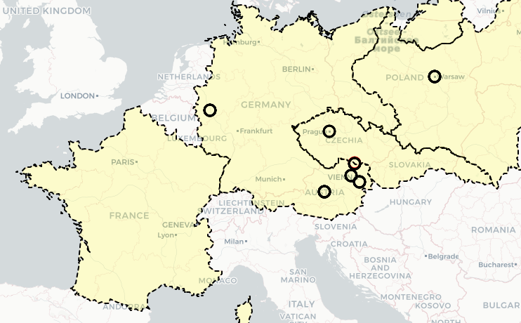

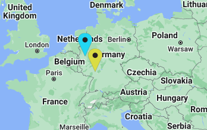

```python
display(Image(filename='tugendreich_auto_map.png', width="450"), Image(filename='tugendreich_YV_map.png', width="450"))
```

### Bericht des Bruders von Samuel Meyer Tugendreich

[figure not shown]

## Namensmauer T

[figure not shown]

## Namensmauer - Ergänzungen

[figure not shown]

## Fragen für die Diskussion

- Führt das *digital turn* zu inklusiven Forschungs- und Erinnerungspraktiken?
- Welche Lücken und Brüche in den Datenbanken der Verfolgten erwarten bzw. finden wir und warum?
- Welche Diskurse und Hierarchien beeinflussen die Namenserfassung?
- Wie können solche Lücken identifiziert und korrigiert werden?